# Corn nitrogen status from UAV hyperspectral imagery

Single-sheet workflow: R6 Combined_real | V8, R1-R2, R5-R6

## Scope and scientific interpretation

Only **`R6 Combined_real`** in `Corn_N_calculations.xlsx` is imported. Its existing `Group` values are used, not reconstructed: `V8` (early), `R1-R2` (mid), and `R5-R6` (late). The workbook contains 288 rows, but check your copy with the audit below.

**Target warning:** `R6_NNI_Combined` appears to be the sum of leaf, stalk, and ear NNI, *not conventional whole-plant NNI*. Furthermore, that column is populated on early-stage rows, apparently carrying a late-stage value across measurements of the same plot. Predicting it from early images would predict a future outcome, not contemporaneous early NNI. Therefore this notebook uses `R1 NNI` in `V8` and `R1-R2`, and `R6_NNI_Combined` only for `R5-R6`. The late target must be revalidated scientifically before claiming whole-plant NNI predictions. Group names are **developmental windows**, not necessarily identical measured targets. Do not pool performance metrics across groups as if their targets have the same definition.

## 1. Packages

```r
# install.packages(c("readxl", "dplyr", "tidyr", "ggplot2", "stringr",
#                    "glmnet", "ranger", "kernlab", "purrr"))
library(readxl)
library(dplyr)
library(tidyr)
library(ggplot2)
library(stringr)
library(glmnet)
library(ranger)
library(kernlab)
library(purrr)
```

## 2. Settings

```r
input_file <- "../data/thiago2024/Corn_N_calculations.xlsx"
sheet_name <- "R6 Combined_real"
output_dir <- "output_R6_Combined_real"
dir.create(output_dir, recursive = TRUE, showWarnings = FALSE)

# Set to path of the Resonon ENVI .hdr when available (recommended).
# Without it, band-to-wavelength mapping is approximate and
# calculated indices should be regarded as exploratory.
hdr_file <- NA_character_

seed <- 2026
n_folds <- 5
alpha_grid <- c(0.25, 0.5, 0.75, 1)
max_bands <- 30
max_indices <- 30
run_late_unvalidated <- FALSE  # Set TRUE only for exploratory late-target modeling
```

## 3. Read **one worksheet only**

```r
stopifnot(file.exists(input_file))
stopifnot(sheet_name %in% excel_sheets(input_file))

corn <- read_excel(input_file, sheet = sheet_name)
names(corn)[1:16]
```

```
 [1] "N_Treatment"     "Study/Field"     "Year"            "Stage"           "Group"           "Date"            "DAP"             "ID"              "NNI_Leaf"
[10] "NNI_Stalk"       "NNI_Ear"         "R1 NNI"          "R6_NNI_Combined" "Band_1"          "Band_2"          "Band_3"
```

```r
required <- c("N_Treatment", "Study/Field", "Year", "Stage", "Group",
              "Date", "DAP", "ID", "R1 NNI", "R6_NNI_Combined")
stopifnot(all(required %in% names(corn)))

band_cols <- paste0("Band_", 5:293)  # 400–1000 nm approximately
stopifnot(all(band_cols %in% names(corn)))

corn <- corn %>%
  mutate(
    across(all_of(c(band_cols, "R1 NNI", "R6_NNI_Combined")), as.numeric),
    Group = as.character(Group),
    Experiment = paste(`Study/Field`, Year, sep = " | "),
    Plot_ID = paste(`Study/Field`, Year, ID, sep = " | "),
    NNI_target = if_else(Group == "R5-R6", `R6_NNI_Combined`, `R1 NNI`),
    Target_definition = if_else(Group == "R5-R6", "R6 combined organ-index sum", "R1 NNI")
  )

corn %>% count(Group, Stage, Experiment, name = "rows")
```

| Group | Stage | Experiment | rows |
| --- | --- | --- | --- |
| R1-R2 | R1 | IxN/Camilla \| 2025 | 48 |
| R1-R2 | R1 | USDA/Ironhorse \| 2024 | 24 |
| R1-R2 | R2 | IxN/Camilla \| 2025 | 48 |
| R1-R2 | R2 | USDA/Ironhorse \| 2024 | 24 |
| R5-R6 | R5 | IxN/Ironhorse \| 2024 | 72 |
| R5-R6 | R6 | USDA/Ironhorse \| 2024 | 24 |
| V8 | V8 | IxN/Camilla \| 2025 | 48 |

## 4. Audit groups, valid targets, repeated plots and source definitions

```r
audit <- corn %>%
  group_by(Group, Experiment, Stage) %>%
  summarise(
    rows = n(),
    plots = n_distinct(Plot_ID),
    measured_target = sum(is.finite(NNI_target)),
    r1_available = sum(is.finite(`R1 NNI`)),
    late_combined_available = sum(is.finite(R6_NNI_Combined)),
    .groups = "drop"
  )
print(audit, n = Inf)
```

| Group | Experiment | Stage | rows | plots | measured_target | r1_available | late_combined_available |
| --- | --- | --- | --- | --- | --- | --- | --- |
| R1-R2 | IxN/Camilla \| 2025 | R1 | 48 | 48 | 48 | 48 | 48 |
| R1-R2 | IxN/Camilla \| 2025 | R2 | 48 | 48 | 48 | 48 | 48 |
| R1-R2 | USDA/Ironhorse \| 2024 | R1 | 24 | 24 | 24 | 24 | 24 |
| R1-R2 | USDA/Ironhorse \| 2024 | R2 | 24 | 24 | 24 | 24 | 24 |
| R5-R6 | IxN/Ironhorse \| 2024 | R5 | 72 | 72 | 72 | 0 | 72 |
| R5-R6 | USDA/Ironhorse \| 2024 | R6 | 24 | 24 | 24 | 0 | 24 |
| V8 | IxN/Camilla \| 2025 | V8 | 48 | 48 | 48 | 48 | 48 |

```r
write.csv(audit, file.path(output_dir, "group_audit.csv"), row.names = FALSE)

# Detect whether the R6 combined target remains constant across plot dates.
corn %>% group_by(Plot_ID) %>%
  summarise(stages = n_distinct(Stage),
            late_target_values = n_distinct(R6_NNI_Combined, na.rm = TRUE),
            .groups = "drop") %>%
  count(stages, late_target_values)
```

| stages | late_target_values | n |
| --- | --- | --- |
| 1 | 1 | 72 |
| 3 | 1 | 72 |

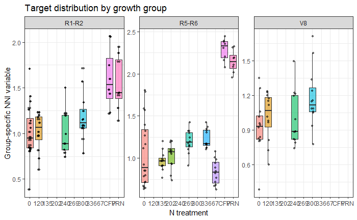

```r
corn %>%
  filter(is.finite(NNI_target)) %>%
  ggplot(aes(x = N_Treatment, y = NNI_target, fill = N_Treatment)) +
  geom_boxplot(outlier.shape = NA, alpha = 0.6) +
  geom_jitter(width = 0.12, alpha = 0.5, size = 1) +
  facet_wrap(~ Group, scales = "free_y") +
  labs(title = "Target distribution by growth group", x = "N treatment",
       y = "Group-specific NNI variable") +
  theme_bw() + theme(legend.position = "none")
```

## 5. Wavelength lookup and spectra

```r
# Read ENVI header wavelengths if available; otherwise approximate using
# the first and last wavelengths reported in the provided sensor screenshot.
read_hdr_wavelengths <- function(path) {
  s <- paste(readLines(path, warn = FALSE), collapse = " ")
  matched <- regmatches(s, regexpr("wavelength\\s*=\\s*\\{[^}]+\\}", s, ignore.case = TRUE))
  if (!length(matched) || !nzchar(matched)) stop("No wavelength array in HDR")
  vals <- sub("^[^{]*\\{", "", matched)
  vals <- sub("\\}.*$", "", vals)
  as.numeric(trimws(strsplit(vals, ",")[[1]]))
}

if (!is.na(hdr_file) && file.exists(hdr_file)) {
  wavelength_all <- read_hdr_wavelengths(hdr_file)
  stopifnot(length(wavelength_all) == 300)
  wavelength_source <- "ENVI header (exact)"
} else {
  wavelength_all <- seq(393.8, 1035.12, length.out = 300)
  wavelength_source <- "APPROXIMATE interpolation; supply HDR for publication"
  warning(wavelength_source)
}

band_map <- data.frame(Band = band_cols, Band_Number = 5:293,
                       Wavelength = wavelength_all[5:293])
head(band_map)
```

|  | Band | Band_Number | Wavelength |
| --- | --- | --- | --- |
| 1 | Band_5 | 5 | 402.3795 |
| 2 | Band_6 | 6 | 404.5244 |
| 3 | Band_7 | 7 | 406.6693 |
| 4 | Band_8 | 8 | 408.8142 |
| 5 | Band_9 | 9 | 410.9591 |
| 6 | Band_10 | 10 | 413.1039 |

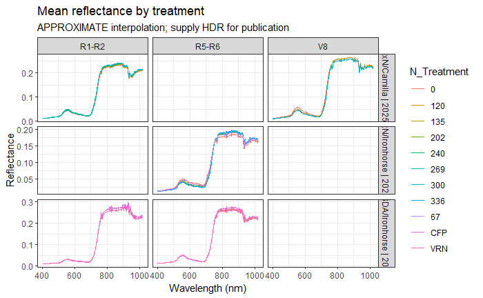

```r
spectral_long <- corn %>%
  select(Experiment, Plot_ID, Group, Stage, N_Treatment, all_of(band_cols)) %>%
  pivot_longer(all_of(band_cols), names_to = "Band", values_to = "Reflectance") %>%
  left_join(band_map, by = "Band")

spectral_mean <- spectral_long %>%
  group_by(Experiment, Group, N_Treatment, Wavelength) %>%
  summarise(mean_reflectance = mean(Reflectance, na.rm = TRUE), .groups = "drop")

ggplot(spectral_mean, aes(Wavelength, mean_reflectance, color = N_Treatment)) +
  geom_line(linewidth = 0.65) +
  facet_grid(Experiment ~ Group, scales = "free_y") +
  labs(title = "Mean reflectance by treatment", x = "Wavelength (nm)",
       y = "Reflectance", subtitle = wavelength_source) +
  theme_bw()
```

## 6. Exploratory PCA (within each group)

```r
run_pca <- function(dat, label) {
  x <- as.matrix(dat[, band_cols])
  ok <- rowSums(!is.finite(x)) == 0
  x <- x[ok, , drop = FALSE]
  d <- dat[ok, , drop = FALSE]
  nonconstant <- apply(x, 2, sd) > 0
  x <- x[, nonconstant, drop = FALSE]
  if (nrow(x) < 4 || ncol(x) < 2) return(NULL)
  p <- prcomp(x, center = TRUE, scale. = TRUE)
  var <- p$sdev^2 / sum(p$sdev^2)
  scores <- bind_cols(d %>% select(Experiment, Plot_ID, Group, N_Treatment),
                      as.data.frame(p$x[, 1:2, drop = FALSE]))
  print(ggplot(scores, aes(PC1, PC2, color = N_Treatment)) +
          geom_point(size = 2.5) +
          labs(title = paste("PCA:", label),
               x = paste0("PC1 (", round(100*var[1], 1), "%)"),
               y = paste0("PC2 (", round(100*var[2], 1), "%)")) +
          theme_bw())
  invisible(p)
}
```

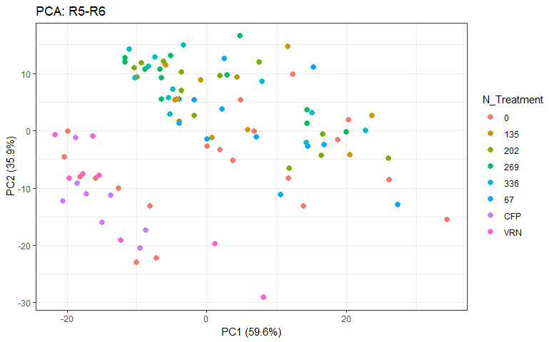

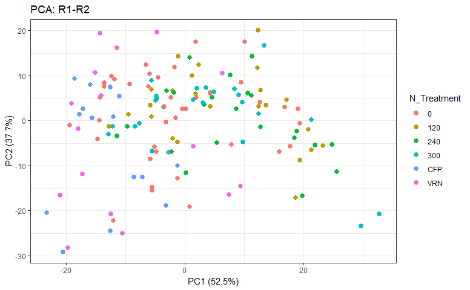

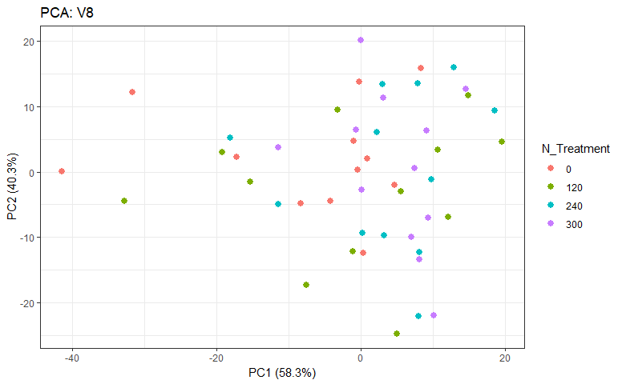

```r
for (g in unique(corn$Group)) {
  run_pca(filter(corn, Group == g), g)
}
```

## 7. Validation design and feature engineering

**Important:** spectral selection and vegetation-index choice are recalculated on each training fold. We evaluate *plots* held out, not spectra from plots also seen during training. Groups contain multiple experiments with different treatments; these results measure held-out-plot performance, **not** transferability to an unseen site or year.

```r
# Assign all observations belonging to a plot to the same fold.
make_folds <- function(plot_ids, k, seed = 2026) {
  u <- unique(as.character(plot_ids))
  set.seed(seed)
  u <- sample(u)
  k <- min(k, length(u))
  if (k < 2) stop("Need at least two distinct plots")
  map <- setNames(rep(seq_len(k), length.out = length(u)), u)
  as.integer(map[as.character(plot_ids)])
}

safe_metrics <- function(obs, pred) {
  data.frame(n = length(obs),
             RMSE = sqrt(mean((obs - pred)^2)),
             MAE = mean(abs(obs - pred)),
             R2 = if (length(obs) > 2 && var(obs) > 0)
               1 - sum((obs - pred)^2) / sum((obs - mean(obs))^2) else NA_real_,
             Bias = mean(pred - obs))
}
```

```r
# Screen bands using an internally CV-tuned Elastic Net on TRAINING plots only.
select_bands <- function(train, seed_local) {
  y <- train$NNI_target
  x <- as.matrix(train[, band_cols])
  keep <- apply(x, 2, sd) > 0
  x <- x[, keep, drop = FALSE]
  if (ncol(x) < 2) stop("Too few variable bands")
  foldid <- make_folds(train$Plot_ID, min(5, n_distinct(train$Plot_ID)), seed_local)
  fits <- lapply(alpha_grid, function(a) {
    cv.glmnet(x, y, alpha = a, foldid = foldid,
              family = "gaussian", standardize = TRUE)
  })
  errors <- vapply(fits, function(m) min(m$cvm), numeric(1))
  best <- fits[[which.min(errors)]]
  b <- as.matrix(coef(best, s = "lambda.1se"))
  nm <- rownames(b)[-1]
  sel <- nm[abs(b[-1, 1]) > 0]
  if (length(sel) == 0) {
    b <- as.matrix(coef(best, s = "lambda.min"))
    sel <- rownames(b)[-1][abs(b[-1, 1]) > 0]
  }
  # If Elastic Net selects many correlated bands, retain largest coefficients.
  coef_vals <- abs(b[sel, 1]); names(coef_vals) <- sel
  sel <- names(sort(coef_vals, decreasing = TRUE))[seq_len(min(length(sel), max_bands))]
  list(bands = sel, alpha = alpha_grid[which.min(errors)])
}
```

```r
# Generate indices *only* from ENet-selected bands.
# Two-band NDI=(Ri-Rj)/(Ri+Rj); ratio=Ri/Rj.
# Region labels constrain biologically interpretable comparisons.
region <- function(w) {
  ifelse(w >= 520 & w < 600, "green",
  ifelse(w >= 620 & w < 680, "red",
  ifelse(w >= 680 & w < 750, "rededge",
  ifelse(w >= 750 & w <= 1000, "nir", "other"))))
}

candidate_pairs <- function(sel) {

  bands <- unique(sel)

  if (length(bands) < 2) {
    return(data.frame(
      a = character(),
      z = character()
    ))
  }

  pairs <- combn(
    bands,
    2
  )

  data.frame(
    a = pairs[1, ],
    z = pairs[2, ]
  )
}

# Model-derived candidate index screening is restricted to TRAINING data.
indices_for_data <- function(dat, pairs) {
  out <- data.frame(row = seq_len(nrow(dat)))
  for (i in seq_len(nrow(pairs))) {
    a <- pairs$a[i]; z <- pairs$z[i]
    den <- dat[[a]] + dat[[z]]
    val <- ifelse(abs(den) > 1e-10, (dat[[a]] - dat[[z]]) / den, NA_real_)
    out[[paste0("NDI_", a, "_", z)]] <- val
  }
  out$row <- NULL
  out
}

pick_indices <- function(train, selection) {

  # Check bands selected by Elastic Net
  selected_regions <- band_map %>%
    filter(Band %in% selection$bands) %>%
    mutate(
      Region = region(Wavelength)
    ) %>%
    count(Region)

  print(selected_regions)

  # Generate candidate NDSIs
  pairs <- candidate_pairs(selection$bands)

  if (nrow(pairs) == 0) {
    return(pairs)
  }

  xi <- indices_for_data(train, pairs)

  scores <- vapply(xi, function(z) {

    ok <- is.finite(z) &
      is.finite(train$NNI_target)

    if (sum(ok) < 5 || sd(z[ok]) == 0) {
      return(0)
    }

    abs(cor(
      z[ok],
      train$NNI_target[ok]
    ))

  }, numeric(1))

  head(
    pairs[
      order(scores, decreasing = TRUE),
      ,
      drop = FALSE
    ],
    max_indices
  )
}
```

## 8. Random Forest and SVM, with held-out-plot CV

```r
fit_predict <- function(train_x, train_y, test_x, model) {
  # Remove constant or nonfinite index columns based on training data.
  good <- vapply(train_x, function(v) all(is.finite(v)) && sd(v) > 0, logical(1))
  train_x <- train_x[, good, drop = FALSE]
  test_x <- test_x[, good, drop = FALSE]
  if (ncol(train_x) == 0 || any(!is.finite(as.matrix(test_x)))) return(rep(NA_real_, nrow(test_x)))
  colnames(train_x) <- make.names(colnames(train_x), unique = TRUE)
  colnames(test_x) <- colnames(train_x)
  if (model == "RF") {
    fit <- ranger(y ~ ., data = data.frame(y = train_y, train_x),
                  num.trees = 500,
                  mtry = max(1, floor(sqrt(ncol(train_x)))),
                  min.node.size = 5, seed = seed)
    return(predict(fit, data = test_x)$predictions)
  }
  # Train-only centering and scaling for radial SVM.
  mu <- vapply(train_x, mean, numeric(1))
  sc <- vapply(train_x, sd, numeric(1))
  xs <- scale(as.matrix(train_x), center = mu, scale = sc)
  ts <- scale(as.matrix(test_x), center = mu, scale = sc)
  fit <- ksvm(x = xs, y = train_y, type = "eps-svr", kernel = "rbfdot",
              C = 1, kpar = "automatic", scaled = FALSE)
  as.numeric(predict(fit, ts))
}
```

```r
evaluate_group <- function(dat, group_name) {
  dat <- dat %>% filter(is.finite(NNI_target))
  valid_spec <- rowSums(!is.finite(as.matrix(dat[, band_cols]))) == 0
  dat <- dat[valid_spec, , drop = FALSE]
  if (n_distinct(dat$Plot_ID) < 8 || nrow(dat) < 12) {
    message("Skipped ", group_name, ": insufficient valid independent plots")
    return(NULL)
  }
  fold <- make_folds(dat$Plot_ID, n_folds, seed)
  outputs <- list(); selected <- list(); i <- 0
  for (f in sort(unique(fold))) {
    train <- dat[fold != f, , drop = FALSE]
    test <- dat[fold == f, , drop = FALSE]
    en <- select_bands(train, seed + f)
    pairs <- pick_indices(train, en)
    if (nrow(pairs) == 0) {
      message("Skipped ", group_name, " fold ", f,
              ": selected bands did not span required spectral regions")
      next
    }
    xtrain <- indices_for_data(train, pairs)
    xtest <- indices_for_data(test, pairs)
    selected[[length(selected) + 1]] <- data.frame(Group = group_name, Fold = f,
      Alpha = en$alpha, Band = en$bands)
    for (model in c("RF", "SVM")) {
      pred <- tryCatch(fit_predict(xtrain, train$NNI_target, xtest, model),
                       error = function(e) {message(conditionMessage(e)); rep(NA_real_, nrow(test))})
      i <- i + 1
      outputs[[i]] <- data.frame(Group = group_name, Fold = f, Model = model,
        Plot_ID = test$Plot_ID, Observed = test$NNI_target, Predicted = pred)
    }
  }
  if (!length(outputs)) return(NULL)
  list(predictions = bind_rows(outputs), selected_bands = bind_rows(selected))
}
```

```r
# Change the switch in Section 2 to explicitly allow exploratory R5-R6 model.
groups_to_run <- c("V8", "R1-R2")
if (run_late_unvalidated) groups_to_run <- c(groups_to_run, "R5-R6")

results <- lapply(groups_to_run, function(g) {
  evaluate_group(filter(corn, Group == g), g)
})
```

| Region | n |
| --- | --- |
| green | 1 |
| nir | 2 |
| other | 6 |
| red | 16 |
| rededge | 5 |

| Region | n |
| --- | --- |

| Region | n |
| --- | --- |
| green | 13 |

| Region | n |
| --- | --- |
| green | 15 |
| nir | 7 |
| rededge | 1 |

| Region | n |
| --- | --- |

| Region | n |
| --- | --- |
| nir | 9 |

| Region | n |
| --- | --- |
| green | 9 |
| nir | 9 |

| Region | n |
| --- | --- |
| green | 5 |
| nir | 8 |

| Region | n |
| --- | --- |
| nir | 8 |
| other | 1 |
| rededge | 7 |

| Region | n |
| --- | --- |
| nir | 1 |

```r
results <- Filter(Negate(is.null), results)

if (length(results)) {
  predictions <- bind_rows(lapply(results, `[[`, "predictions"))
  band_selection <- bind_rows(lapply(results, `[[`, "selected_bands"))
  write.csv(predictions, file.path(output_dir, "heldout_plot_predictions.csv"), row.names = FALSE)
  write.csv(band_selection, file.path(output_dir, "elastic_net_bands_by_fold.csv"), row.names = FALSE)
} else {
  message("No eligible model runs. See audit and selected-band warnings.")
}
```

## 9. Report the model accuracy and inspect the chosen bands

| Group | Model | n | RMSE | MAE | R2 | Bias |
| --- | --- | --- | --- | --- | --- | --- |
| R1-R2 | RF | 116 | 0.3438290 | 0.2561327 | 0.04726997 | -0.005383264 |
| R1-R2 | SVM | 116 | 0.3663636 | 0.2680345 | -0.08170680 | -0.012285583 |
| V8 | RF | 29 | 0.2258510 | 0.1704988 | 0.16554022 | 0.044412049 |
| V8 | SVM | 29 | 0.2357471 | 0.1925786 | 0.09081161 | 0.085169437 |

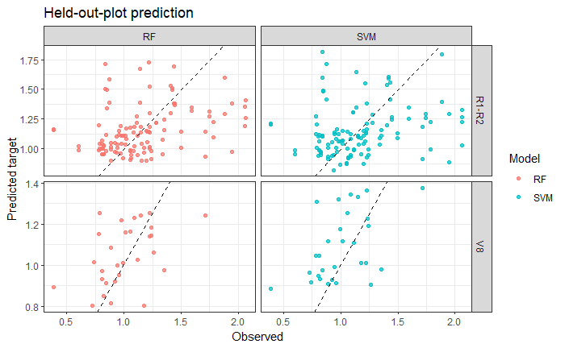

```r
if (exists("predictions")) {
  performance <- predictions %>%
    filter(is.finite(Predicted)) %>%
    group_by(Group, Model) %>%
    group_modify(~ safe_metrics(.x$Observed, .x$Predicted)) %>%
    ungroup()
  print(performance)
  write.csv(performance, file.path(output_dir, "group_model_performance.csv"), row.names = FALSE)

  print(ggplot(filter(predictions, is.finite(Predicted)),
               aes(Observed, Predicted, color = Model)) +
    geom_point(alpha = 0.75) +
    geom_abline(slope = 1, intercept = 0, linetype = 2) +
    facet_grid(Group ~ Model, scales = "free") +
    theme_bw() + labs(title = "Held-out-plot prediction", y = "Predicted target"))
}
```

```r
if (exists("band_selection") && nrow(band_selection)) {
  frequency <- band_selection %>%
    count(Group, Band, name = "Selected_in_folds") %>%
    left_join(band_map, by = "Band") %>%
    arrange(Group, desc(Selected_in_folds))
  print(frequency %>% group_by(Group) %>% slice_head(n = 15), n = Inf)
  write.csv(frequency, file.path(output_dir, "band_selection_frequency.csv"), row.names = FALSE)
}
```

| Group | Band | Selected_in_folds | Band_Number | Wavelength |
| --- | --- | --- | --- | --- |
| R1-R2 | Band_251 | 4 | 251 | 930.0207 |
| R1-R2 | Band_252 | 4 | 252 | 932.1656 |
| R1-R2 | Band_253 | 4 | 253 | 934.3105 |
| R1-R2 | Band_254 | 4 | 254 | 936.4554 |
| R1-R2 | Band_256 | 4 | 256 | 940.7452 |
| R1-R2 | Band_257 | 4 | 257 | 942.8900 |
| R1-R2 | Band_258 | 4 | 258 | 945.0349 |
| R1-R2 | Band_260 | 3 | 260 | 949.3247 |
| R1-R2 | Band_261 | 3 | 261 | 951.4696 |
| R1-R2 | Band_156 | 1 | 156 | 726.2569 |

[output cut: 20 more lines]

## 10. Research decisions before publication

1. Verify critical N dilution calculations. The `R6_NNI_Combined` column **must not** be reported as standard whole-plant NNI merely because its values are numeric.
2. `V8` and `R1-R2` currently use `R1 NNI`; check whether the R1 values are contemporaneous with **each** sampling date. If not, rename the objective as prediction of later R1 NNI from earlier reflectance, or provide contemporaneous early NNI values.
3. The selection code uses training-only screening, but RF/SVM hyperparameters above are baseline values. A final manuscript should implement nested plot-grouped tuning for RF (`mtry`, `min.node.size`) and SVM (`C`, `sigma`, `epsilon`).
4. Distinct study sites may have different nitrogen-management labels and canopy conditions. Validation on a separate year/site is a stronger generalization test than randomly held-out plots.
5. Supply exact ENVI wavelengths to make vegetation index definitions defensible. Band endpoints are only approximately calibrated without the header.

```r
band_map %>%
  filter(Band %in% selection$bands) %>%
  mutate(
    Region = region(Wavelength)
  ) %>%
  count(Region)
```

[output not shown]

### 11.1 Settings for the raw-band comparison

```r
raw_output <- file.path(output_dir, "raw_band_comparison")
dir.create(raw_output, recursive = TRUE, showWarnings = FALSE)

# Final research run: test k = all bands, all bands - 1, ..., 1
raw_predictor_step <- 1L

# For quick debugging only, use 10; switch back to 1 for the actual analysis.
# raw_predictor_step <- 10L

# False = rerun. True = read each completed group's CSV if present.
reuse_raw_csv <- TRUE

# Same groups as the NDSI analysis above (R5-R6 disabled by default).
raw_groups <- groups_to_run
```

### 11.2 Training-only ordering of raw bands

```r
rank_raw_bands <- function(train) {
  y <- train$NNI_target
  x <- as.matrix(train[, band_cols, drop = FALSE])

  # Constant or invalid bands in this training fold are not usable.
  usable <- vapply(seq_len(ncol(x)), function(j) {
    all(is.finite(x[, j])) && sd(x[, j]) > 0
  }, logical(1))

  x <- x[, usable, drop = FALSE]
  if (ncol(x) < 1) return(character())

  # Use *training data only*. No test labels enter ranking.
  scores <- vapply(seq_len(ncol(x)), function(j) {
    val <- suppressWarnings(
      cor(x[, j], y, method = "spearman")
    )
    if (is.finite(val)) abs(val) else 0
  }, numeric(1))

  colnames(x)[order(scores, decreasing = TRUE)]
}
```

### 11.3 Run RF and SVM at every raw-band predictor count

```r
evaluate_raw_path <- function(dat, group_name) {

  dat <- dat %>% filter(is.finite(NNI_target))
  good_rows <- rowSums(
    !is.finite(as.matrix(dat[, band_cols, drop = FALSE]))
  ) == 0
  dat <- dat[good_rows, , drop = FALSE]

  if (n_distinct(dat$Plot_ID) < 8 || nrow(dat) < 12) {
    message("Skipping raw-band comparison for ", group_name,
            ": insufficient independent plots")
    return(NULL)
  }

  fold <- make_folds(dat$Plot_ID, n_folds, seed)
  outputs <- list()
  counter <- 0L

  for (f in sort(unique(fold))) {
    train <- dat[fold != f, , drop = FALSE]
    test <- dat[fold == f, , drop = FALSE]

    ranked <- rank_raw_bands(train)
    p <- length(ranked)
    if (p < 1) next

    # Every possible predictor count from p down to 1 by default.
    k_values <- unique(c(seq(p, 1L, by = -raw_predictor_step), 1L))
    k_values <- sort(k_values, decreasing = TRUE)

    message("Group ", group_name, " | fold ", f,
            " | usable bands ", p, " | sizes ", length(k_values))

    for (k in k_values) {
      predictors <- ranked[seq_len(k)]
      train_x <- as.data.frame(train[, predictors, drop = FALSE])
      test_x <- as.data.frame(test[, predictors, drop = FALSE])

      for (method in c("RF", "SVM")) {
        estimate <- tryCatch(
          fit_predict(train_x, train$NNI_target, test_x, method),
          error = function(e) {
            message("Error in ", group_name, " fold ", f,
                    " k=", k, " ", method, ": ", conditionMessage(e))
            rep(NA_real_, nrow(test))
          }
        )

        counter <- counter + 1L
        outputs[[counter]] <- data.frame(
          Group = group_name,
          Fold = f,
          Model = method,
          Predictor_Set = "Raw bands",
          Predictors = k,
          Max_Predictors_Fold = p,
          Plot_ID = test$Plot_ID,
          Observed = test$NNI_target,
          Predicted = as.numeric(estimate)
        )
      }
    }
  }

  if (!length(outputs)) return(NULL)
  bind_rows(outputs)
}
```

### 11.4 Run all groups and save raw-band predictions

```r
raw_results <- list()

for (g in raw_groups) {
  path_g <- file.path(raw_output, paste0("raw_predictions_", g, ".csv"))

  if (reuse_raw_csv && file.exists(path_g)) {
    message("Reading saved raw-band path for ", g)
    raw_results[[g]] <- read.csv(path_g, stringsAsFactors = FALSE)
  } else {
    result_g <- evaluate_raw_path(filter(corn, Group == g), g)
    if (!is.null(result_g)) {
      write.csv(result_g, path_g, row.names = FALSE)
      raw_results[[g]] <- result_g
    }
  }
}

raw_predictions <- bind_rows(raw_results)
if (nrow(raw_predictions) > 0) {
  write.csv(raw_predictions,
            file.path(raw_output, "raw_predictions_all_groups.csv"),
            row.names = FALSE)
}
```

### 11.5 Accuracy at every predictor count, compared with NDSIs

```r
raw_performance <- data.frame()

if (nrow(raw_predictions) > 0) {
  raw_performance <- raw_predictions %>%
    filter(is.finite(Predicted)) %>%
    group_by(Group, Model, Predictor_Set, Predictors) %>%
    group_modify(~ safe_metrics(.x$Observed, .x$Predicted)) %>%
    ungroup()

  write.csv(raw_performance,
            file.path(raw_output, "raw_performance_every_k.csv"),
            row.names = FALSE)

  print(raw_performance %>%
          group_by(Group, Model) %>%
          arrange(desc(Predictors), .by_group = TRUE) %>%
          slice_head(n = 5), n = Inf)
}
```

| Group | Model | Predictor_Set | Predictors | n | RMSE | MAE | R2 | Bias |
| --- | --- | --- | --- | --- | --- | --- | --- | --- |
| R1-R2 | RF | Raw bands | 289 | 144 | 0.3296842 | 0.2536315 | 0.07181611 | 0.006443121 |
| R1-R2 | RF | Raw bands | 288 | 144 | 0.3308381 | 0.2553072 | 0.06530728 | 0.006451060 |
| R1-R2 | RF | Raw bands | 287 | 144 | 0.3318818 | 0.2559475 | 0.05940069 | 0.006607000 |
| R1-R2 | RF | Raw bands | 286 | 144 | 0.3314416 | 0.2565295 | 0.06189412 | 0.006921158 |
| R1-R2 | RF | Raw bands | 285 | 144 | 0.3311052 | 0.2547738 | 0.06379740 | 0.008135538 |
| R1-R2 | SVM | Raw bands | 289 | 144 | 0.3367080 | 0.2605759 | 0.03184583 | 0.004739713 |
| R1-R2 | SVM | Raw bands | 288 | 144 | 0.3397839 | 0.2643688 | 0.01407600 | -0.001716422 |
| R1-R2 | SVM | Raw bands | 287 | 144 | 0.3333019 | 0.2572381 | 0.05133393 | -0.007647329 |
| R1-R2 | SVM | Raw bands | 286 | 144 | 0.3380142 | 0.2622660 | 0.02431966 | -0.003521160 |
| R1-R2 | SVM | Raw bands | 285 | 144 | 0.3346966 | 0.2579139 | 0.04337812 | -0.005100215 |

[output cut: 10 more lines]

```r
# The NDSI metrics already created in Section 9 are the comparator.
ndsi_comparison <- data.frame()
if (exists("performance") && nrow(performance) > 0) {
  ndsi_comparison <- performance %>%
    mutate(Predictor_Set = "ENet-selected NDSIs",
           Predictors = NA_integer_) %>%
    select(Group, Model, Predictor_Set, Predictors, n, RMSE, MAE, R2, Bias)
}

if (nrow(raw_performance) > 0) {
  comparison_every_k <- bind_rows(
    raw_performance %>%
      select(Group, Model, Predictor_Set, Predictors, n, RMSE, MAE, R2, Bias),
    ndsi_comparison
  )

  write.csv(comparison_every_k,
            file.path(raw_output, "raw_vs_NDSI_comparison.csv"),
            row.names = FALSE)
}
```

### 11.6 Plot model accuracy as the number of bands decreases

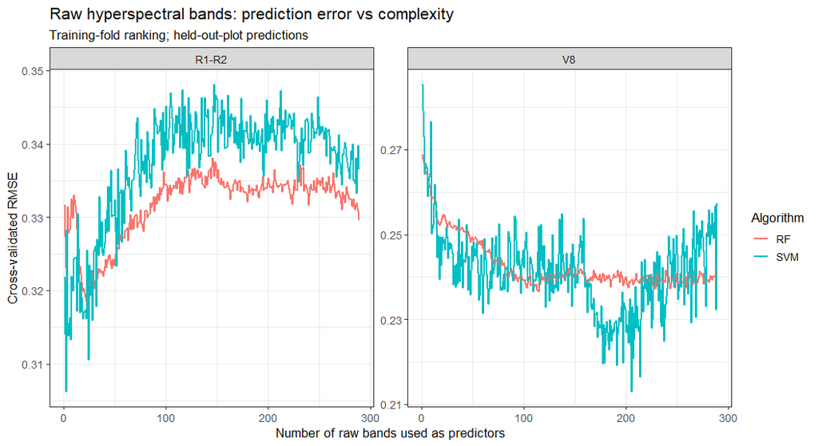

```r
if (nrow(raw_performance) > 0) {
  ggplot(raw_performance,
         aes(x = Predictors, y = RMSE, color = Model)) +
    geom_line(linewidth = 0.8) +
    geom_point(size = 0.5, alpha = 0.5) +
    facet_wrap(~ Group, scales = "free_y") +
    labs(title = "Raw hyperspectral bands: prediction error vs complexity",
         subtitle = "Training-fold ranking; held-out-plot predictions",
         x = "Number of raw bands used as predictors",
         y = "Cross-validated RMSE",
         color = "Algorithm") +
    theme_bw(base_size = 13)
}
```

```r
if (nrow(raw_performance) > 0) {
  ggplot(raw_performance,
         aes(x = Predictors, y = R2, color = Model)) +
    geom_hline(yintercept = 0, linetype = 2, color = "gray50") +
    geom_line(linewidth = 0.8) +
    facet_wrap(~ Group) +
    labs(title = "Raw band complexity vs held-out-plot R²",
         x = "Number of raw bands used as predictors",
         y = "Cross-validated R²",
         color = "Algorithm") +
    theme_bw(base_size = 13)
}
```

[output not shown]

### 11.7 Find a simpler model, accounting for fold-to-fold error variation

This descriptive **one-standard-error** rule selects the **smallest k** whose mean fold RMSE is within one standard error of the minimum mean fold RMSE. It does not create a new independent held-out evaluation of that selected k. A repeat with nested tuning is needed before reporting the selected-k result as final predictive accuracy.

```r
raw_fold_metrics <- data.frame()
raw_simple <- data.frame()

if (nrow(raw_predictions) > 0) {
  raw_fold_metrics <- raw_predictions %>%
    filter(is.finite(Predicted)) %>%
    group_by(Group, Model, Predictors, Fold) %>%
    summarise(
      Fold_RMSE = sqrt(mean((Observed - Predicted)^2)),
      .groups = "drop"
    )

  raw_summaries <- raw_fold_metrics %>%
    group_by(Group, Model, Predictors) %>%
    summarise(
      Mean_RMSE = mean(Fold_RMSE),
      SE_RMSE = sd(Fold_RMSE) / sqrt(n()),
      Folds = n(),
      .groups = "drop"
    )

  raw_simple <- raw_summaries %>%
    group_by(Group, Model) %>%
    group_modify(~ {
      best <- .x[which.min(.x$Mean_RMSE), , drop = FALSE]
      threshold <- best$Mean_RMSE + best$SE_RMSE
      eligible <- .x[.x$Mean_RMSE <= threshold, , drop = FALSE]
      simplest <- eligible[which.min(eligible$Predictors), , drop = FALSE]
      simplest$Best_k <- best$Predictors
      simplest$Best_mean_RMSE <- best$Mean_RMSE
      simplest$Threshold_1SE <- threshold
      simplest
    }) %>%
    ungroup()

  write.csv(raw_simple,
            file.path(raw_output, "exploratory_simplest_models_1SE.csv"),
            row.names = FALSE)
  print(raw_simple, n = Inf)
}
```

| Group | Model | Predictors | Mean_RMSE | SE_RMSE | Folds | Best_k | Best_mean_RMSE | Threshold_1SE |
| --- | --- | --- | --- | --- | --- | --- | --- | --- |
| R1-R2 | RF | 1 | 0.3282201 | 0.02659565 | 5 | 24 | 0.3137274 | 0.3388356 |
| R1-R2 | SVM | 1 | 0.3194345 | 0.02166457 | 5 | 2 | 0.3027507 | 0.3279902 |
| V8 | RF | 2 | 0.2582143 | 0.03316810 | 5 | 114 | 0.2285338 | 0.2600057 |
| V8 | SVM | 17 | 0.2290188 | 0.03558314 | 5 | 205 | 0.2079916 | 0.2337848 |

### 11.8 Poster-focused comparison: full spectrum, simpler raw bands, NDSI

```r
if (nrow(raw_performance) > 0) {
  full_raw <- raw_performance %>%
    group_by(Group, Model) %>%
    filter(Predictors == max(Predictors)) %>%
    ungroup() %>%
    mutate(Approach = "All raw bands")

  simplest_raw <- raw_simple %>%
    select(Group, Model, Predictors) %>%
    inner_join(raw_performance,
               by = c("Group", "Model", "Predictors")) %>%
    mutate(Approach = "Exploratory simplest raw")

  poster_comparison <- bind_rows(
    full_raw,
    simplest_raw,
    ndsi_comparison %>% mutate(Approach = "ENet-selected NDSIs")
  ) %>%
    select(Group, Model, Approach, Predictors, n, R2, RMSE, MAE, Bias)

  print(poster_comparison, n = Inf)
  write.csv(poster_comparison,
            file.path(raw_output, "poster_model_comparison.csv"),
            row.names = FALSE)
}
```

| Group | Model | Approach | Predictors | n | R2 | RMSE | MAE | Bias |
| --- | --- | --- | --- | --- | --- | --- | --- | --- |
| R1-R2 | RF | All raw bands | 289 | 144 | 0.07181611 | 0.3296842 | 0.2536315 | 0.006443121 |
| R1-R2 | SVM | All raw bands | 289 | 144 | 0.03184583 | 0.3367080 | 0.2605759 | 0.004739713 |
| V8 | RF | All raw bands | 289 | 48 | 0.02866127 | 0.2410970 | 0.1847326 | 0.014574197 |
| V8 | SVM | All raw bands | 289 | 48 | -0.10599176 | 0.2572660 | 0.2133781 | -0.022712267 |
| R1-R2 | RF | Exploratory simplest raw | 1 | 144 | 0.06086385 | 0.3316236 | 0.2619200 | 0.003772845 |
| R1-R2 | SVM | Exploratory simplest raw | 1 | 144 | 0.11565397 | 0.3218046 | 0.2487416 | -0.026286426 |
| V8 | RF | Exploratory simplest raw | 2 | 48 | -0.19079610 | 0.2669471 | 0.2117085 | 0.024915944 |
| V8 | SVM | Exploratory simplest raw | 17 | 48 | 0.04095384 | 0.2395666 | 0.1890856 | -0.009679674 |
| R1-R2 | RF | ENet-selected NDSIs | NA | 116 | 0.04726997 | 0.3438290 | 0.2561327 | -0.005383264 |
| R1-R2 | SVM | ENet-selected NDSIs | NA | 116 | -0.08170680 | 0.3663636 | 0.2680345 | -0.012285583 |

[output cut: 2 more lines]